# Table of Contents

Modified from [Introduction to Complex Analysis](https://primer-computational-mathematics.github.io/book/c_mathematics/complex_analysis/3_complex_functions.html)

## Visualization

### Graph Plots

Mathematicians define a *function* like this: each value of a defining set of values $X$ relates to a value in a targeting set. The most common appearance of functions $X$ is an interval on the real axis, and for each $x\epsilon X$ a real value $f(x)$ is assigned. In mathematical notation: $f : I \to \mathbb{R}$, where $I \subseteq \mathbb{R}$ is an interval of the real axis. The visualization of such a function is called a **graph**. In Python the most common library for visualization is [matplotlib](https://matplotlib.org/). Here the sub-library 'pyplot' is imported, for use as the shortcut 'plt'. As a user you can choose another naming of the shortcut. However, most programmers commonly choosing the one taken here.

[figure not shown]

```python
import numpy as np
import matplotlib.pyplot as plt
fig, ax = plt.subplots(figsize=(5,2))
```

The third command initializes a figure (fig) with coordinate axes (ax). The numbers of the figsize parameter in the brackets may to have been adjusted according to the operating system and display that is used. With the following code lines a graph is produced, as shown. The figure depicts the graph of $f(x)=x^2$.

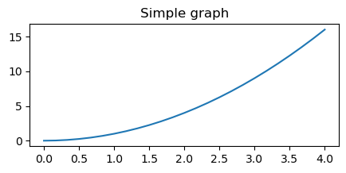

```python
fig, ax = plt.subplots(figsize=(5,2))
x = np.linspace(0,4,25); y = x*x
plt.plot (x,y)
ax.set_title('Simple graph')
plt.show()
```

```python
print (x)
```

```
[0.         0.16666667 0.33333333 0.5        0.66666667 0.83333333
 1.         1.16666667 1.33333333 1.5        1.66666667 1.83333333
 2.         2.16666667 2.33333333 2.5        2.66666667 2.83333333
 3.         3.16666667 3.33333333 3.5        3.66666667 3.83333333
 4.        ]
```

In the same line a second vector 'y' is produced. 'x*x' initiates elementwise multiplication of the elements of the x-vector. Let's see!

```python
print (y)
```

```
[ 0.          0.02777778  0.11111111  0.25        0.44444444  0.69444444
  1.          1.36111111  1.77777778  2.25        2.77777778  3.36111111
  4.          4.69444444  5.44444444  6.25        7.11111111  8.02777778
  9.         10.02777778 11.11111111 12.25       13.44444444 14.69444444
 16.        ]
```

All mathematical operations can be performed for scalars (single values) and for vectors. Using vectors enables the programmer to produce simple and compact code. Python has a rich palette of operations not only for vectors, but also for other variable types, as matrices, lists, strings, etc. We will introduce them only as needed. Most of vector and vector operations can be performed using the same symbols used for basic mathematical operations with real numbers.

**Task 1**: Modify the above code to plot a graph of the function $x^3/(5+x)$ in the interval $I=-4<=x<=4$!

In the following we mainly want to deal with complex functions, i.e. for which the defining set and the function set are both the space of complex numbers, i.e. 2D spaces. While the 1D example above altogether has 2 dimensions, in the case of complex functions there are four dimensions. Imaging and graphical representation is thus more complicated. But lets start with a simple example of a real valued function.

### Contour Plotting

Let's add one more dimension, by looking how to visualize a real-valued function, defined on a 2-dimensional domain $D$. The 2D domain $D$ can be conceived as part of or the entire complex plane. The easiest way of visualization is to trace contour lines, i.e. lines within $D$, on which the function takes the same value. The following code shows how a contour-line plot can easily be constructed.

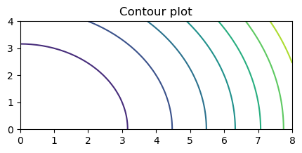

```python
fig, ax = plt.subplots(figsize=(5, 2))
x = np.linspace(0, 8, 50)
y = np.linspace(0, 4, 50)
X, Y = np.meshgrid(x, y)
Z = X*X+Y*Y
plt.contour(X, Y, Z)
ax.set_title('Contour plot')
plt.show()
```

A few commands are necessary to create the plot. Here two vectors are required, one for selected values on the x-axis, one for the y-axis, here denoted as x and y respectively. The 'meshgrid' command (from 'numpy') creates two matrices X and Y representing a rectangular grid (or mesh) of points. In the X matrix we find all x-coordinates, in the Y matrix all y-coordinates. Note that Python is case-sensitive, which means that x is different from X, and y different from Y. The matrix Z is the store for the values of the function that is to be plotted. The last command, 'contour' from 'matplotlib', initiates the plot of contour lines, i.e. lines of positions with the same function value. Obviously in this case these are parts of circles.

Some other options make the plots more fancy. One may add a legend, labels on axes and contour lines, grid lines, use various line types and areal colours according to various colormaps etc. For contour lines it makes sense to add labels, showing the value that they reprresent.

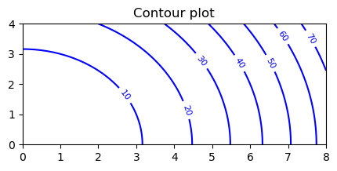

```python
fig, ax = plt.subplots(figsize=(5, 2))
x = np.linspace(0, 8, 50)
y = np.linspace(0, 4, 50)
X, Y = np.meshgrid(x, y); Z = X**2+Y**2
contours = plt.contour(X, Y, Z, colors = 'b')
plt.clabel(contours, inline = True, fontsize=8, fmt = '%2.0f')
ax.set_title('Contour plot')
plt.show()
```

Here contourlines are blue, as specified by the 'colors' parameter in the contuor call. In 'clabel' the position of the labels, their fontsize and format is specified. '2.0f' means floating point without decimals. Instead of labeling, one can fill the space between the contour lines by colors. For this we have the 'contourf' command.

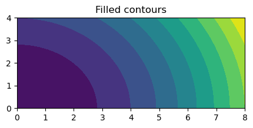

```python
fig, ax = plt.subplots(figsize=(5, 2))
plt.contourf(X, Y, Z, 10)
ax.set_title('Filled contours')
plt.show()
```

Note that now there are 10 contours, corresponding to the 4th parameter in the 'contourf' call. The space between the contours is filled by colors from a colormap. The default colormap is viridis, which uses yellow for high values and dark blue for low values.

**Task 2**: Show contours of the function $x^3+y^3$ in the domain $-4<=x<=4$ and $-4<=y<=4$!

Let's change the colormap, add labels on the axes, and put a legend using the 'colorbar' function.

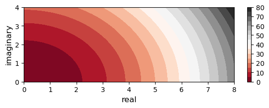

```python
fig, ax = plt.subplots(figsize=(7, 2))
plt.contourf(X, Y, Z, 15, cmap = 'RdGy')
plt.colorbar()
plt.xlabel ('real',fontsize=12); plt.ylabel ('imaginary',fontsize=12)
plt.show()
```

You may also look in the matplotlib tutotrial [color maps](https://matplotlib.org/3.1.1/tutorials/colors/colormaps.html). There are different classes of colormaps: sequential, diverging, cyclic and qualitative. When there is a pronounced mean value (such as zero in our example) then it is convenient to use a divergent map, where the colors on both sides of the mean change by lightness. Here some other options in this class.

[figure not shown]

Above we chose the 'RdGy' option, which uses black for high values and brownish red for low values. Intermediate high values are depicted by different shades of grey, intermediate low values by different shades of the red. Thus it makes sense to color the mean value by white color. These colourings are especially conveneient in cases, where the mean value is zero. Then positive and negative values can be visually distinguished by the colour - with white for values near zero.

**Task 3**: Use one of the diverging color maps for the function of Task 2! Increse the number of contours by giving a numeric input parameter (50) in the 'contourf' command.

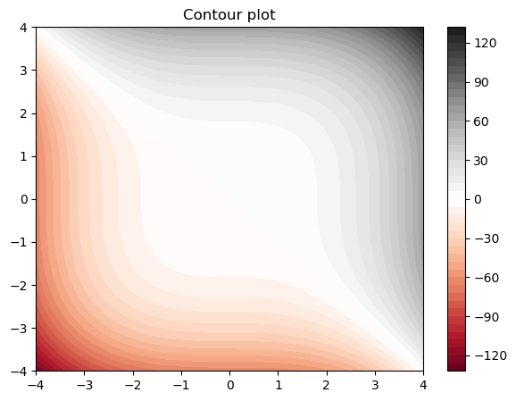

```python
fig, ax = plt.subplots(figsize=(7, 5))
x = np.linspace(-4, 4, 50)
y = np.linspace(-4, 4, 50)
X, Y = np.meshgrid(x, y); Z = X*X*X+Y*Y*Y
plt.contourf(X, Y, Z, 50, cmap='RdGy')
plt.colorbar()
ax.set_title('Contour plot')
plt.show()
```

The appearance of a plot can also be regulated by using style-files and 'rcParams'. 'style' and 'rcParams' make default specifications when a graphic object is intialized. There are a lot of graphic options, like fonts, fontsize for label, title, markersize, default color, background color, line thickness, and many more. One may use a style sheet in which these settings are done to provide a certain established style. In order to find the styles that are available in your installation use:

```python
print(plt.style.available)
```

```
['Solarize_Light2', '_classic_test_patch', '_mpl-gallery', '_mpl-gallery-nogrid', 'bmh', 'classic', 'dark_background', 'fast', 'fivethirtyeight', 'ggplot', 'grayscale', 'seaborn-v0_8', 'seaborn-v0_8-bright', 'seaborn-v0_8-colorblind', 'seaborn-v0_8-dark', 'seaborn-v0_8-dark-palette', 'seaborn-v0_8-d…
```

Here, as an example, the switch to black and white.

[figure not shown]

```python
fig, ax = plt.subplots(figsize=(7, 2))
plt.style.use('grayscale')
plt.rcParams['axes.facecolor'] = 'lightgray'
plt.contourf(X, Y, Z, 15)
plt.colorbar()
plt.xlabel ('x',fontsize=12); plt.ylabel ('y',fontsize=12)
plt.show()
```

Graphic parameters are set in a 'rc'-file, which can be accessed using the 'rcParams' command. You can have a look at all settings using 'print (plt.rcParams)'. You can change each paramter individually. Parameters of 'rcParams' will be overwritten, when the style is changed. Some parameters of 'rcParams' are ignored in style sheets, see matplotlib.style.use. To reset to default use:

```python
plt.style.use('default')
plt.rcParams['axes.facecolor'] = 'white'
```

Let's switch to functions that connect complex numbers to complex numbers. The following constructs a matrix of complex numbers under the name 'Z' and creates a plot.

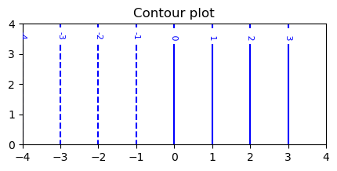

```python
fig, ax = plt.subplots(figsize=(5, 2))
x = np.linspace(-4, 4, 50)
y = np.linspace(-0, 4, 50)
X, Y = np.meshgrid(x, y); Z = X+1j*Y
contours = plt.contour(X, Y, Z.real ,colors = 'b')
plt.clabel(contours, inline=True, fontsize=8, fmt = '%2.0f')
ax.set_title('Contour plot')
plt.show()
```

The following demonstrates how to create a rectangular mesh of complex numbers and to visualize the real and complex part of a complex function in a single figure.

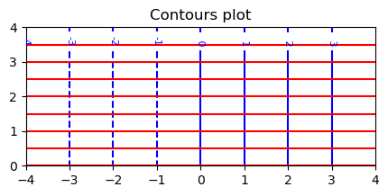

```python
fig, ax = plt.subplots(figsize=(5, 2))
x = np.linspace(-4, 4, 50)
y = np.linspace(-0, 4, 50)
X, Y = np.meshgrid(x, y); Z = X+1j*Y
contours = plt.contour(X, Y, Z.real ,colors = 'b')
plt.clabel(contours, inline=True, fontsize=8, fmt = '%2.0f')
plt.contour(X, Y, Z.imag ,colors = 'r')
ax.set_title('Contours plot')
plt.show()
```

**Task 4**: Extend the coding to put labels on the contours of the imaginary function values!

**Task 5**: Use filled contours for the imaginary function values!

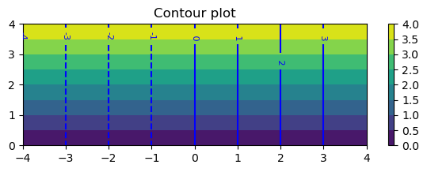

```python
fig, ax = plt.subplots(figsize=(7, 2))
x = np.linspace(-4, 4, 50)
y = np.linspace(-0, 4, 50)
X, Y = np.meshgrid(x, y); Z = X+1j*Y
contours = plt.contour(X, Y, Z.real ,colors = 'b')
plt.contourf(X, Y, Z.imag)
plt.colorbar()
plt.clabel(contours, inline=True, fontsize=8, fmt = '%2.0f')
ax.set_title('Contour plot')
plt.show()
```

Let's examine a more intersting function: $f(z)=z^2$.

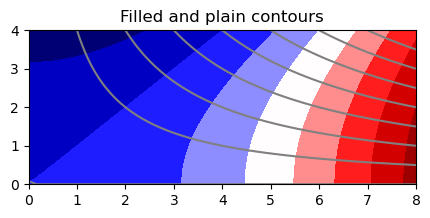

```python
fig, ax = plt.subplots(figsize=(5, 2))
x = np.linspace(0, 8, 50)
y = np.linspace(0, 4, 50)
X, Y = np.meshgrid(x, y)
Z = X + 1j*Y; F = Z*Z

plt.contourf(X, Y, np.real(F),cmap='seismic')
plt.contour(X, Y, np.imag(F),colors='grey')
ax.set_title('Filled and plain contours')
plt.show()
```

Z contains the in each element the elementwise complex square of the position stored in Z. The colors represent the real part of the complex function, here plotted with colormap 'seismic'. The contours (here all in grey) represent the contour lines of the imaginary part of the function. With this method we are able to visualize both the real and the imaginary part of a complex function in the one picture. For a better understanding, recall that the imaginary part of the function is $2xy$ and thus vanishes on both axes. We will learn that this visualization has applications in several fields of natural sciences and engineering.

**Task 6**: Produce a square plot of the function $f(z)=z^4$ in the domain $0<=x<=4$ and $0<=y<=4$.

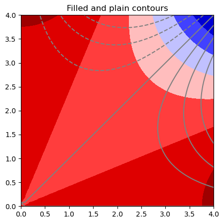

```python
fig, ax = plt.subplots(figsize=(5, 5))
x = np.linspace(0, 4, 50)
y = np.linspace(0, 4, 50)
X, Y = np.meshgrid(x, y)
Z = X + 1j*Y; F = Z**4

plt.contourf(X, Y, np.real(F),cmap='seismic')
plt.contour(X, Y, np.imag(F),colors='grey')
ax.set_title('Filled and plain contours')
plt.show()
```

For better understanding of the contour lines note that the imaginary part of the fourth power is given by $4xy(x^2-y^2)$. Thus all points on the coordinate axes and on the diagonal of the first sector have zero value. Below the diagonal the function is positive. Above the diagonal there are negative values, as indicated by dashed lines.

### Image Colouring

The 'imshow' command offers another way of showing 2D data are conceived as representation of an image.  
The difference between contouring and imaging is demonstrated by the following. The 'subplot' command allows to show both plots next to each other. There are two subplots, which are related to the axes 'ax1' and 'ax2'. The first number in the argument in the 'add_subplot' command denotes the total number of plots in a column, the second number gives the number of sub-plots in row, the third is the number of actual plot. Here there is only one row, so the first number is a 1. There are two figures in that row, i.e. 2 is the second number. And the individual plots are identified by the third number, here 1 or 2. The left figure is done with 'contourf', the right uses 'imshow'.

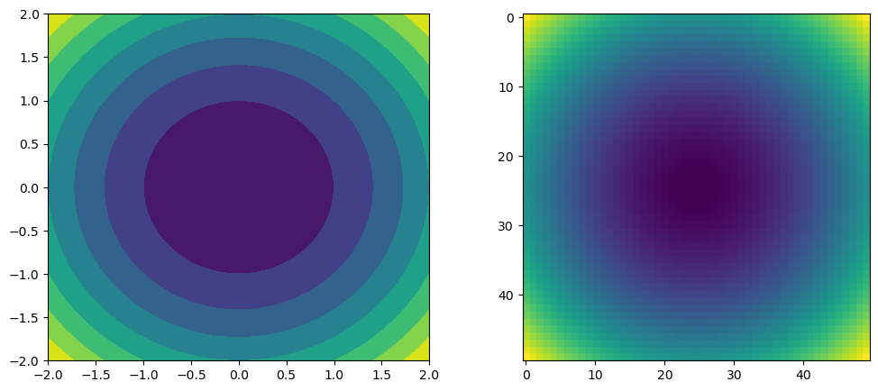

```python
fig = plt.figure(figsize=(12, 5))
x = np.linspace(-2, 2, 50)
y = np.linspace(-2, 2, 50)
X, Y = np.meshgrid(x, y); Z = X + 1j*Y
F = Z*Z

ax1 = fig.add_subplot(121); ax2 = fig.add_subplot(122)
ax1.contourf (X,Y,np.abs(F))
ax2.imshow (np.abs(F))
plt.show()
```

The figure above has 50 $\times$ 50 pixels. The coloring of the figure on the left is related to the contours. The space between adjacent contours is filled by one color. In the right the color of each pixel depends on the function value. Note that in the right figure values on the axes denote pixels.

**Task 7**: Change the code using 'imshow' command for the real part of $f(z)=z^2$ and contours for the imaginary part.

A more interesting visualisation is obtained, if one colors the absolute values in orders of magnitude. The code below shows how this can be done for the unit interval (excluding 0).

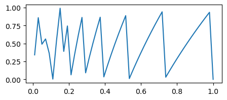

```python
fig, ax = plt.subplots(figsize=(5, 2))
x = np.linspace(0.01, 1, 50)
A = np.log(np.abs(x)) * 10 / np.pi; A = A - A//1
plt.plot (x,A)
plt.show()
```

In order to understand how the different parameters determine the outcome, change the factor behind the logarithm (for example use 3 or 20).

Lets utilize this scaling for the coloring of an image. Here we use the the unit function in the interval $-2\leq x \leq 2$ and $-2 \leq y \leq 2$ as example.

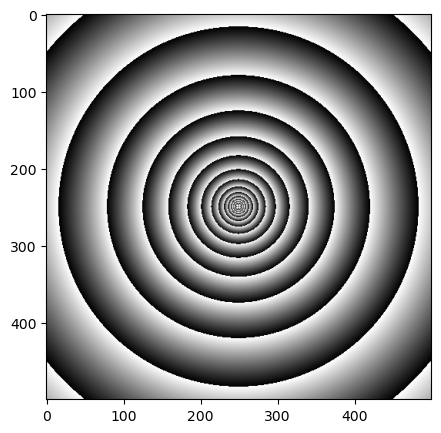

```python
fig, ax = plt.subplots(figsize=(5, 5))
x = np.linspace(-2, 2, 500)
y = np.linspace(-2, 2, 500)
X, Y = np.meshgrid(x, y); Z = X + 1j*Y

A = np.log(np.abs(Z)) * 10 / np.pi; A = A - A//1
amin = np.min(A); amax = np.max(A)
V = (A-amin) / (amax-amin)
plt.imshow (V,cmap='binary')
plt.show()
```

### Colour Wheel Plots

A question we need to think about is how to plot complex functions. In the section on exponential function below we will present some other techniques, but let us now jump immediately to one which will often be most useful for us: **[domain coloring](https://en.wikipedia.org/wiki/Domain_coloring)** or a **colour wheel graph**.

The default colormaps utilize the RGB color-system that is based on the three fundamental colors red, green and blue. As an example, as seen already, in the 'viridis' system high values are shown in yellow, low values in dark blue. In the grey-tone system high values are black and low values in white. An alternative coloring system is HSV (hue, saturation, value). Transformations from HSV to RGB is performed by the 'hsv_to_rgb' command of the 'matplotlib.colors' sub-library. All three parameters require values between 0 and 1.

Saturation $S$ represents the purity of colors. For $S=1$ all colors are pure (do not contain white). As $S$ decreases the colors look more fade. The brightness $V$ increases from zero to 1. At $V=0$, all colours look dark.

[figure not shown]

The HSV model is represented by a solid cylinder having the radius and height 1. The angle represents the hue $H$, the radius represents the saturation $S$, and the height the brightness $V$.

Sectioning this cylinder with a plane perpendicular to its vertical axis, at the height $V=v$, one gets a color wheel whose complex parameterization is $z=Se^{2\pi i H}$. As hue $H$ varies from 0 to 1, the corresponding colors vary in this color wheel such that at $2\pi H$, with $H\in\{0, 1/6, 1/3, 1/2, 2/3, 5/6, 1\}$ are located respectively the colors red, yellow, green, cyan, blue, magenta, and red again. The image below illustrates the color wheel of brightness $V=1$.

[figure not shown]

In this representation, the phase (argument) is assigned a hue on the colour wheel, so we call this a **phase portrait**. The colour brightness will also be modified to present lines of constant modulus (or absolute value).

By doing this we can represent a complex function in a plane, as we would with real functions. It will be very easy for us to spot several very important features of functions. Let us start with the complex function $f(z) = z$. Here we demonstrate the effect of the saturation parameter $s$, which has the value of 0.9 in the left image, and 0.3 in the right image.

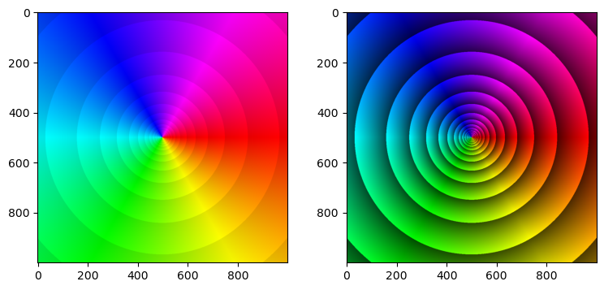

```python
from matplotlib.colors import hsv_to_rgb
fig = plt.figure(figsize=(9, 4))
x = np.linspace(-2, 2, 1000); y = x
X, Y = np.meshgrid(x, y); Z = X + 1j*Y

ax1 = fig.add_subplot(121); ax2 = fig.add_subplot(122)
A = np.log(np.abs(Z)) * 10 / np.pi; A = A - A//1
amin = np.min(A); amax = np.max(A)
H = (np.angle(-Z) + np.pi) / (2*np.pi)                # hue

s = 0.9                                               # saturation
V = (A-amin) / (amax-amin) * (1-s) + s                # brightness
img = hsv_to_rgb(np.dstack((H, np.ones(Z.shape), V)))
ax1.imshow(img)
s = 0.3                                               # saturation
V = (A-amin) / (amax-amin) * (1-s) + s                # brightness
img = hsv_to_rgb(np.dstack((H, np.ones(Z.shape), V)))
ax2.imshow(img)
plt.show()
```

In the figure it is clearly seen on the left figure for $f(z) = z$ that the red colour corresponds to arg$f(z) \approx 0$, cyan to arg$f(z) \approx \pi$ and so on. The clockwise colour order is red-green-blue-red, which indicates that $z=0$ is a zero of the function $f(z) = z$.

We can put all relevant transformations in a function that we define our own. We call the function 'phaseplot'.

```python
def phaseplot(ax, F):
    s = 0.7                                                 # saturation
    A = np.log(np.abs(F)) * 10 / np.pi; A = A - A//1
    amin = np.min(A); amax = np.max(A)
    H = (np.angle(-F) + np.pi) / (2*np.pi)                  # hue
    V = (A-amin) / (amax-amin) * (1-s) + s                  # brightness
    img = hsv_to_rgb(np.dstack((H, np.ones(F.shape), V)))
    ax.imshow(img, extent=[min(x), max(x), min(y), max(y)])
```

Let us demonstrate here with the function $f(z) = 1/z$. This is a rational function with a pole at the origin.

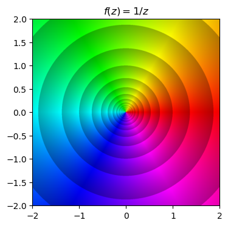

```python
fig, ax = plt.subplots(figsize=(4, 4))
phaseplot (ax, 1/Z)
ax.set_title('$f(z) = 1/z$')
plt.show()
```

Now on the plot, showing $g(z) = 1/z$, the colour wheel is reversed to be red-blue-green-red. This is because $z=0$ is a pole of $1/z$. In general, if a point $z$ is a zero of $1/f$ then it is a pole of $f$. Therefore, we can usually tell the domain of the function from its colour wheel plot. Note that in the 'imshow' command the axes were were set to the intervals on the real and imaginary axes. Now look at this:

[figure not shown]

```python
fig = plt.figure(figsize=(9, 4))
ax1 = fig.add_subplot(121); ax2 = fig.add_subplot(122)
phaseplot (ax1, Z*Z)
phaseplot (ax2, 1/Z/Z)
ax1.set_title('$f(z) = z^2$')
ax2.set_title('$f(z) = 1/z^2$')
plt.show()
```

Which functions are visualized here and what else is different from the preceding figures?

This example shows that $f(z) = z^5$ has an quintuple root at zero and we see that we go five times around the colour wheel:

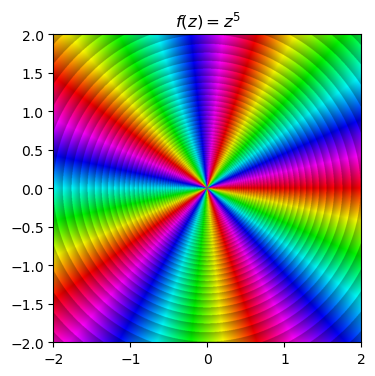

```python
fig, ax = plt.subplots(figsize=(4, 4))
phaseplot (ax, Z**5)
ax.set_title('$f(z) = z^5$')
plt.show()
```

Let's turn to the rational function $f(z) = (z^3-1)/z$.

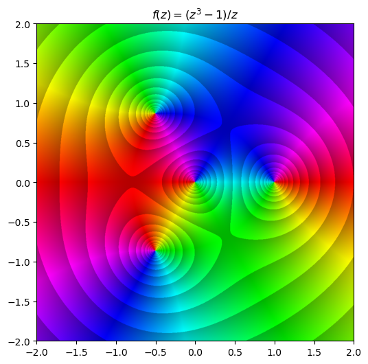

```python
fig, ax = plt.subplots(figsize=(6, 6))
phaseplot (ax, (Z**3-1)/Z)
ax.set_title(r'$f(z) = (z^3-1)/z$')
plt.show()
```

Following the explanations, given above, clearly the pole at $z$=0 and the three zeros can be identified. Additionally, we can see the order of the zeros and poles by the number of times we go around the colour wheel.

**Task 8**: Visualize $f(z)=(z-0.5(1+i))/z^2$ in the square $(x,y) \epsilon [-2,2] \times [-2,2]$

**Task 9**: Visualize $f(z)=(z^6-1)/(z^{12}+1)$ in the square $ (x,y) \epsilon [-1.3,1.3] \times [-1.3,1.3]$

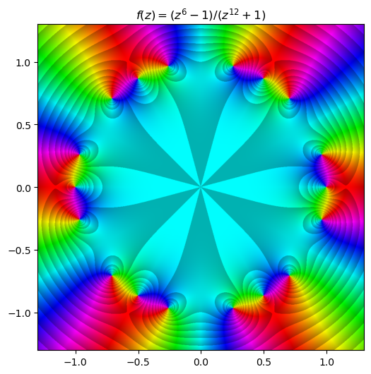

```python
fig, ax = plt.subplots(figsize=(6, 6))
x = np.linspace(-1.3, 1.3, 1000); y = x
X, Y = np.meshgrid(x, y); Z = X + 1j*Y
phaseplot (ax, (Z**6-1)/(Z**12+1))
ax.set_title('$f(z) = (z^6-1)/(z^{12}+1)$')
plt.show()
```

The function has 6 zeros and 12 poles, all located on the unit circle.

In this chapter up to now we delt with rational functions. We can use the coloring also for non-rational functions. The following three figures show the colour wheel plots for the functiomns $(e^z-1)/z^2$, $cos(z)/z^2$ and $sinh(z)/z^4$. All functins are not defined for $z=0$. In complewx analysis we call this an **isolated singularity**. What can you discover from the grphs about the singularity at the origin?

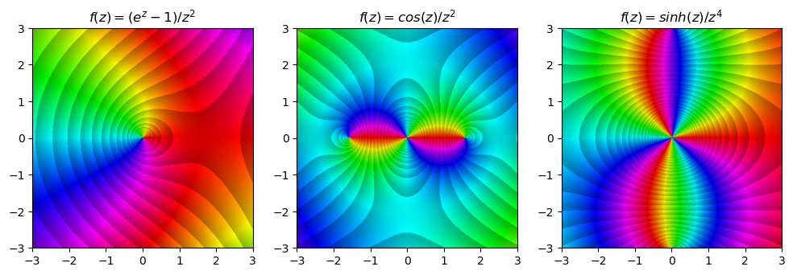

```python
fig = plt.figure(figsize=(12, 6))
ax1 = fig.add_subplot(131); ax2 = fig.add_subplot(132); ax3 = fig.add_subplot(133)
x = np.linspace(-3, 3, 500); y = x
X, Y = np.meshgrid(x, y); Z = X + 1j*Y

phaseplot (ax1, ((np.exp(Z)-1)/Z/Z))
ax1.set_title('$f(z) = (e^z-1)/z^2$')
phaseplot (ax2, np.cos(Z)/Z/Z)
ax2.set_title('$f(z) = cos(z)/z^2$')
phaseplot (ax3, np.sinh(Z)/(Z**4))
ax3.set_title('$f(z) = sinh(z)/z^4$')
plt.show()
```

What about $sin(z)/z$ and $(1-cos(z))/z^2$? Both have a singularity at the origin!

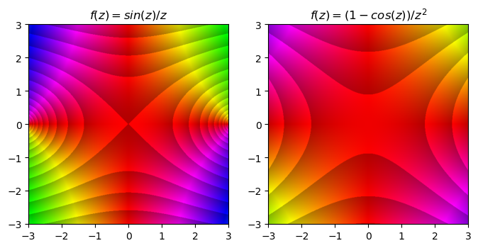

```python
fig = plt.figure(figsize=(8, 4))
ax1 = fig.add_subplot(121); ax2 = fig.add_subplot(122)
phaseplot (ax1, np.sin(Z)/Z)
phaseplot (ax2, (1-np.cos(Z))/Z/Z)
ax1.set_title('$f(z) = sin(z)/z$')
ax2.set_title('$f(z) = (1-cos(z))/z^2$')
plt.show()
```

Finally let's check the function $f(z) = exp(1/z)$.

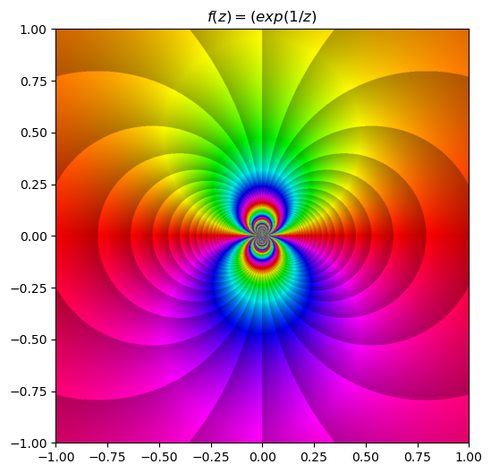

```python
fig, ax = plt.subplots(figsize=(6, 6))
x = np.linspace(-1, 1, 1000); y = x
X, Y = np.meshgrid(x, y); Z = X + 1j*Y
phaseplot (ax, np.exp(1/Z))
ax.set_title('$f(z) = (exp(1/z)$')
plt.show()
```

Mathematicians have shown that differentiable functions have only three primary types of isolated singularities: removable, poles, and essential. All three exhibit distinct, recognizable visual signatures.

### 3D Visualizations

A visual representation in 3D sometimes gives a better impression on what is happening near a zero or a pole. As example let's examine the complex logarithm. First we construct the 3D view of the real values. For this the 'mplot3' toolbox has to be imported from the 'mpl_toolkits' library.

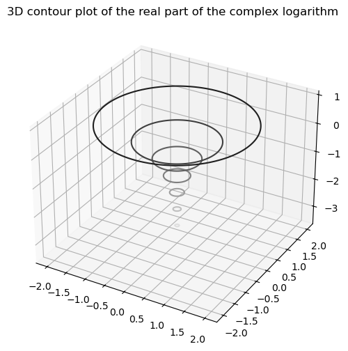

```python
from mpl_toolkits import mplot3d
x = np.linspace(-2, 2, 100)
X, Y = np.meshgrid(x, x)
Z = X + 1j * Y
F = np.real(np.log(Z))

fig = plt.figure(figsize=(6,6)); ax = plt.axes(projection='3d')
ax.contour3D(X, Y, F, cmap='binary')
ax.set_title('3D contour plot of the real part of the complex logarithm')
plt.show()
```

The 'contour3D' plot shows concentric circles with decreasing values when approaching the origin. Obviously this represents a cone. As such it is relevant in engineering applications. One example is the drawdown of the groundwater table near a pumping well.

Another 3D visualization is called by the 'wireframe' function. The 'view' command sets the angles, by which the observer is watching.

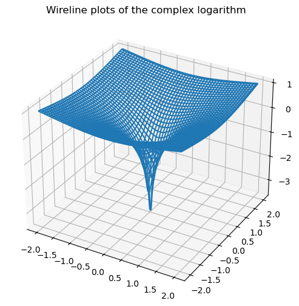

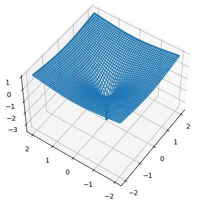

```python
fig = plt.figure(figsize=(6,6))
ax = plt.axes(projection='3d')
ax.plot_wireframe(X, Y, F)
ax.set_title('Wireline plots of the complex logarithm')
plt.show()
ax = plt.axes(projection='3d')
ax.view_init(50, 215)
ax.plot_wireframe(X, Y, F)
plt.show()
```

Let's use the 3D visualization for the real and the imaginary part of the complex logarithm.Here we use the 'plot_surface' function of the library.

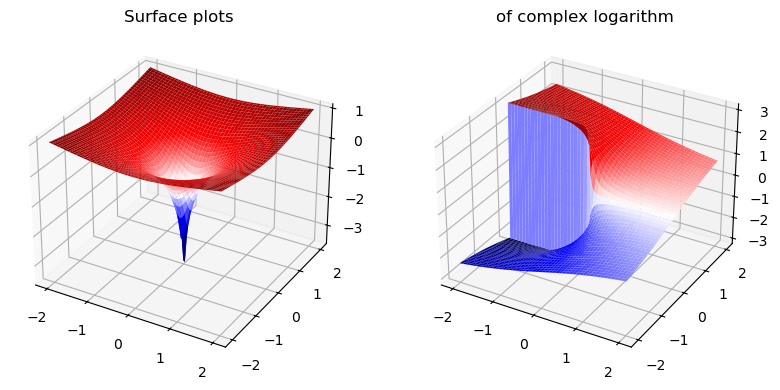

```python
from mpl_toolkits import mplot3d
x = np.linspace(-2, 2, 100)
X, Y = np.meshgrid(x, x)
Z = X + 1j * Y
F = np.log(Z)

fig = plt.figure(figsize=plt.figaspect(0.5))
ax = fig.add_subplot(1,2,1,projection='3d');
ax.plot_surface(X, Y, np.real(F), cmap='seismic')
ax.set_title('Surface plots')
ax = fig.add_subplot(1,2,2,projection='3d');
ax.plot_surface(X, Y, np.imag(F), cmap='seismic')
ax.set_title('of complex logarithm')
plt.show()
```

Here the 3D visualization is showing surfaces, performed using the 'plot_surface' command. On the left, we see the above mentioned cone in colour. Negative values are shown in blue, positive in red. The plot on the right illustrates more clearly, what is happening with the imaginary values. There is a continuous transition from the negative values in the forth quadrant to the positive values in the first quadrant. Along the negative real axis, the interface between the second and third quadrant there is something different: there is a jump between positive and negative values. We call this a branch cut.

### Branch Cuts

We say the principal value of the complex logarithm has a branch cut at the negative real axis.

See below the color-wheel visualization of the complex logarithm.

[figure not shown]

```python
x = np.linspace(-2, 2, 500)
X, Y = np.meshgrid(x, x); Z = X + 1j * Y
F = np.log(Z)

fig, ax = plt.subplots(figsize=(5,5))
s = 0.9
A = np.log(np.abs(F)) * 10 / (np.pi); A = A - A//1
amin = np.min(A); amax = np.max(A)
H = (np.angle(-F) + np.pi) / (2*np.pi)
V = (A-amin) / (amax-amin) * (1-s) + s
img = hsv_to_rgb(np.dstack((H, np.ones(F.shape), V)))
ax.imshow(img, extent=[min(x), max(x), min(y), max(y)])
ax.set_title('Color-wheel plot of the complex logarithm')
plt.show()
```

The logarithm has a zero at $z$=1. Note that the usual coloring pattern fails at $z=0$ along the negative real axis.

Lets look at the complex logarithm in the same complex domain using contours of real and imaginary parts!

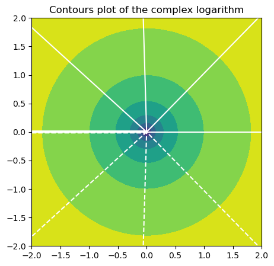

```python
x = np.linspace(-2, 2, 100)
X, Y = np.meshgrid(x, x)
Z = X + 1j * Y
F = np.log(Z)

fig, ax = plt.subplots(figsize=(5,5))
plt.contourf(X, Y, np.real(F))
plt.contour(X, Y, np.imag(F),colors='white')
ax.set_title('Contours plot of the complex logarithm')
plt.show()
```

The real part is shown by concentric circles around the origin. The imaginary part has straight lines meeting in the origin. In the upper half of the figure the lines are solid, indicating positive values. In the lower half the lines are broken, indicating negative values. The negative real axis has a solid and a broken line. This indicates the jump that we have seen already in the 3D visualization.

In order to make the complex logarithm unique one has to cut out the negative real axis. We call this a branch cut. To be exact, I should say that for the uniqueness of the complex logarithm the location of the branch cut is not unique. The cut should include the origin and from there proceed to inifinity.